# CAPSTONE

Saurabh Yadav

25 October 2018

## Executive summary

#### In this milestone we have to analyse a corpus of data of different languages of dataset.The corpus data is used here is in english. Now we have to use the corpus to do some exploratory analysis.In the analysis the following points will be consider:

#### 1. The size of file and the numbers of lines and charcaters

#### 2.The most texted and using uni gram words.

#### 3. The most texted and using bi-gram words.

#### 4. The most texted and using tri-gram words.

### This exploratory anaysis part is divided in two parts

#### 1.PART-1: Preperation and cleaning of corpus and converting them in accessible form

#### 2.PART-2: Exploratory Analysis

## PART-1:Preperation and cleaning of corpus and converting them in accessible form

### downloading the data

```r
##Since dowloading will take long time so I am putting the code below as comment

#link<-"https://d396qusza40orc.cloudfront.net/dsscapstone/dataset/Coursera-SwiftKey.zip"
#file<-download.file(url = link,destfile = "capstone.zip")
```

#### Loading the required library

```r
library(ggplot2)
library(tm)
library(NLP)
```

#### Loading the dataset

```r
####Creating the corpus
blog<-readLines("en_US.blogs.txt",warn = FALSE)
tweets<-readLines("en_US.twitter.txt",warn = FALSE)
news<-readLines("en_US.news.txt",warn = FALSE)
```

### Corpus analysis

```r
info<-data.frame(dataset=c("en_US.blogs","en_US.news","en_US.twitter"),number_of_lines=c(length(blog),length(news),length(tweets)),number_of_characters=c(sum(nchar(blog)),sum(nchar(news)),sum(nchar(tweets))),file_size=c(200,196,159))

info
```

```
##         dataset number_of_lines number_of_characters file_size
## 1   en_US.blogs          899288            208361438       200
## 2    en_US.news           77259             15683765       196
## 3 en_US.twitter         2360148            162384825       159
```

### Creating the sample data set only 10 percent of the each en_US dataset

```r
###taking the sample index
sampleblog_index<-sample(seq_len(length(blog)),size = length(blog)*0.10)
samplenews_index<-sample(seq_len(length(news)),size = length(news)*0.10)
sampletweets_index<-sample(seq_len(length(tweets)),size = length(tweets)*0.10)


blog<-blog[sampleblog_index]
news<-news[samplenews_index]
tweets<-tweets[sampletweets_index]
```

### Functions for cleaning the sample dataset

```r
rempunct<-function(x)(gsub("[[:punct:]]","",x))
remdigit<-function(x)(gsub("[0-9]", "",x))
remurl<-function(x)(gsub("http[[:alnum:]]*","",x))
remnonascii<-function(x)(iconv(x,"latin1","ASCII",""))
removeap<-function(x)(gsub("'","",x))
lowercase<-function(x)tolower(x)
```

### creating a data frame and applying the function on it

```r
df1<-data.frame(c(blog,news,tweets))
df<-df1$c.blog..news..tweets.
df<-as.character(df)
df<-rempunct(df)
df<-remdigit(df)
df<-remurl(df)
df<-remnonascii(df)
df<-removeap(df)
df<-lowercase(df)
```

### Creating All UNI-GRAM ,BI-GRAM and TRI-GRAM words

```r
count<-0
strspl<-strsplit(df, " ")
allwords_onegram<-c()
####converting all the words in large vector for one gram
for(i in 1:length(strspl)){
  d<-strspl[[i]]
  for (j in d) {
    count=count+1
    allwords_onegram[count]<-j
  }
}
count<-0

##creating all bi gram words

allwords_bigram<-c()
for (i in 1:length(strspl)) {
  d1<-strspl[[i]]
  d2<-ngrams(d1,2)
  d3<-vapply(d2, paste, "" ,collapse=" ")

  for (j in d3) {
    count=count+1
    allwords_bigram[count]<-j
  }
}

count<-0

##creating all tri gram words
allwords_trigram<-c()
for (i in 1:length(strspl)) {

  d1<-strspl[[i]]
  d2<-ngrams(d1,3)
  d3<-vapply(d2, paste, "" ,collapse=" ")

  for (j in d3) {
    count=count+1
    allwords_trigram[count]<-j
  }

}
```

### Creating the data frame for uni fram,bigram and trigram words

```r
one_gram_words<-data.frame(table(as.matrix(allwords_onegram)))
bi_gram_words<-data.frame(table(as.matrix(allwords_bigram)))
tri_gram_words<-data.frame(table(as.matrix(allwords_trigram)))

words<-one_gram_words[order(one_gram_words$Freq,decreasing = T),]
bigram<-bi_gram_words[order(bi_gram_words$Freq,decreasing = T),]
trigram<-tri_gram_words[order(tri_gram_words$Freq,decreasing = T),]
```

#### Cleaning the most common words from the uni-gram words

```r
common_word<-c("a","i","you","he","she","it","they","we","are","is","am","has","had","was","were","been","will","to","the","in","or","and","at","might","could","for","of","on","my","that","this","so","as","not","all","its","im","from","out","if","have","me","an","can","could","","his","her","them","there","us","him","would")
lg<-words$Var1%in%common_word
allwords<-words[!lg,]
```

## 2.PART-2: Exploratory Analysis

### Analysis of uni gram words

#### 1. Top 30 uni gram words

```r
a1<-allwords$Var1
a2<-allwords$Freq
unigrams<-data.frame(words=a1,Frequency=a2)

unigrams[1:30,]
```

```
##    words Frequency
## 1   with     47199
## 2     be     40699
## 3    but     33450
## 4   your     26648
## 5   just     25361
## 6   what     22351
## 7   like     22314
## 8     up     22129
## 9  about     21367
## 10   one     21099
## 11    do     19991
## 12    by     19003
## 13  when     18855
## 14   get     18718
```

[output cut: 16 more lines]

#### 2. first 25 words are too obvious so we will use only words after 25

#### 3. Plot for unigram analysis

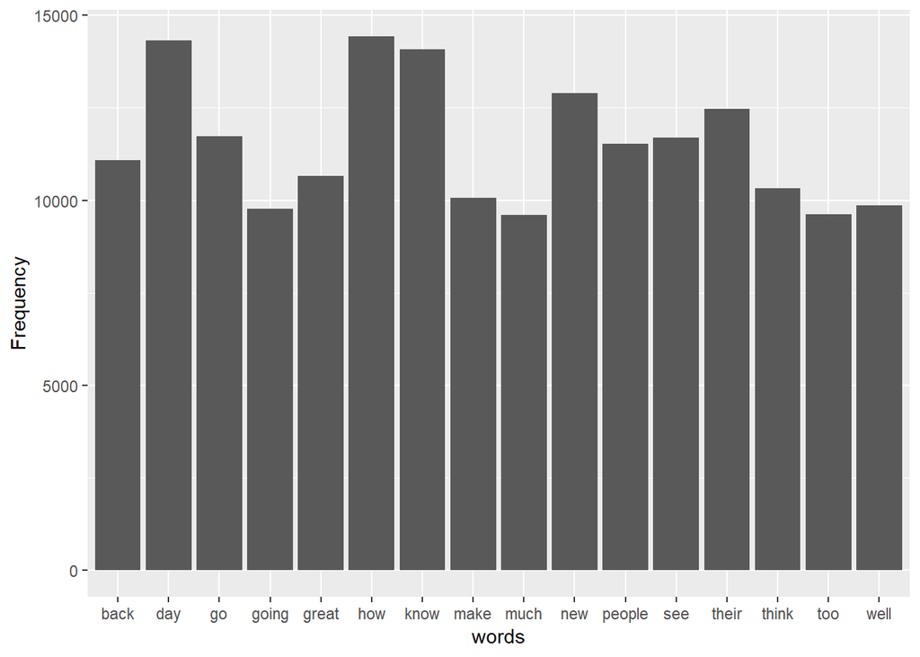

```r
##taking only the most used general words
mostusedwords<-unigrams[25:40,]
ggplot(mostusedwords,aes(words,Frequency))+geom_bar(stat = "identity")
```

### Analysis of bi gram words

#### 1. Top 30 bigrams

```r
a3=bigram$Var1
a4=bigram$Freq
bigram1<-data.frame(words=a3,Frequency=a4)
bigram1[1:30,]
```

```
##       words Frequency
## 1    of the     25615
## 2    in the     24221
## 3   for the     13531
## 4    to the     13336
## 5    on the     12691
## 6     to be     11787
## 7    at the      8823
## 8    i have      7967
## 9   and the      7692
## 10     is a      7500
## 11    i was      7434
## 12     in a      7188
## 13    and i      7162
## 14   it was      7128
```

[output cut: 16 more lines]

#### 2.first 30 lines are not any informative. So we will use after the 30 bi grams in data frame

```r
bigram1[30:40,]
```

```
##         words Frequency
## 30     that i      4937
## 31     with a      4903
## 32     one of      4839
## 33    i think      4816
## 34       of a      4810
## 35     i love      4802
## 36    this is      4666
## 37    have to      4665
## 38     to see      4513
## 39      but i      4511
## 40 thanks for      4388
```

#### 4. Plot for bi gram analysis

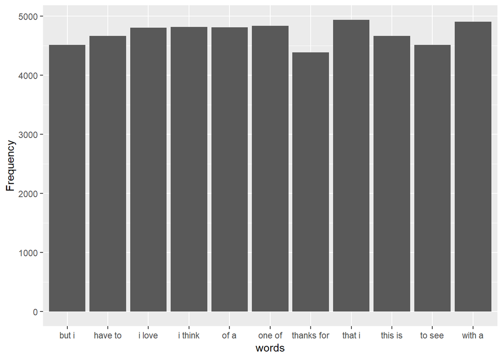

```r
most_bigram_used<-bigram1[30:40,]
ggplot(most_bigram_used,aes(words,Frequency))+geom_bar(stat = "identity")
```

### Analysis of tri gram words

#### 1. Top 30 trigrams

```r
a5=trigram$Var1
a6=trigram$Freq
trigram1<-data.frame(words=a5,Frequency=a6)
trigram1[1:30,]
```

```
##                 words Frequency
## 1      thanks for the      2272
## 2          one of the      2147
## 3            a lot of      1915
## 4           i want to      1366
## 5         going to be      1317
## 6                          1298
## 7             to be a      1289
## 8            i have a      1104
## 9            it was a      1069
## 10 looking forward to      1060
## 11          i have to      1050
## 12         the end of       995
## 13      thank you for       989
## 14       cant wait to       979
```

[output cut: 16 more lines]

#### 2.first 10 lines are not any informative. So we will use after the 10 tri grams in data frame

```r
trigram1[10:20,]
```

```
##                 words Frequency
## 10 looking forward to      1060
## 11          i have to      1050
## 12         the end of       995
## 13      thank you for       989
## 14       cant wait to       979
## 15        im going to       968
## 16        i dont know       966
## 17         out of the       963
## 18         i love you       949
## 19         be able to       928
## 20          i need to       927
```

#### 4. Plot for tri gram analysis

```r
most_trigram_used<-trigram1[10:20,]
```

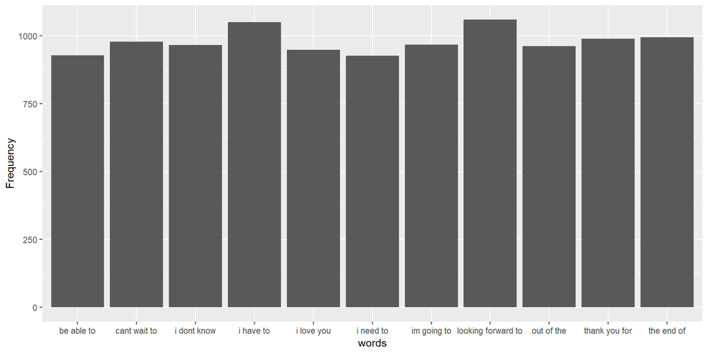

```r
ggplot(most_trigram_used,aes(words,Frequency))+geom_bar(stat = "identity")
```